# User guide for performing automatic gating with `cytometree`

Chariff Alkhassim, Boris Hejblum

2019-01-12

# Introduction to `cytometree`

`cytometree` is a package that implements a binary tree algorithm for the analysis of cytometry data.

Its core algorithm is based on the construction of a binary tree, whose nodes represents cell subpopulations.

## Binary tree construction

1. At each node, observed cells (or “events”) and markers are modeled by both a normal distribution (so *unimodal*), and a mixture of 2 normal distributions (so *bimodal*).
2. Splitting of the events at each node is done according to a normalized difference of AIC between the two distributional fit (unimodal or bimodal), allowing to pick the marker that best splits those data.
3. When AIC normalized differences $D$ are not significant anymore, the tree has been constructed, and the cells have been automatically gated (i.e. partitioned).

## Post-hoc annotation

Given the unsupervised nature of the binary tree, some of the available markers may not be used to find the different cell populations present in a given sample. To recover a complete annotation, we defined, as a post processing procedure, an annotation method which allows the user to distinguish two (or three) expression levels per marker.

# Examples of analysis with `cytometree`

## Diffuse large B-cell lymphoma dataset with 3 markers

In this example, we will use a diffuse large B-cell lymphoma dataset (from the [FlowCAP-I challenge](http://flowcap.flowsite.org/), with only 3 markers.

### Automatic gating step

First, we need to load the package `cytometree` and we can have a look at the data:

```r
library(cytometree)
data(DLBCL)
dim(DLBCL)
```

```
## [1] 5524    4
```

```r
head(DLBCL)
```

```
##   FL1 FL2 FL4 label
## 1 416 251 293     2
## 2 210  93 184     2
## 3 387 300 233     2
## 4 403 438 288     2
## 5 399 128 116     2
## 6 538 288 189     2
```

We have 3 markers measured `FL1`, `FL2`, `FL4` as well as the `label` obtained from manual gating, and 5524 cells.

```r
# getting the only the cell events with the 3 markers measured:
cellevents <- DLBCL[, c("FL1", "FL2", "FL4")]
# storing the maanual gating reference from FlowCAP-I:
manual_labels <- DLBCL[, "label"]
```

The function `CytomeTree` builds the binary tree according to our algorithm, that gives the automatic gating (given in the resulting `labels` attribute):

```r
# Build the binary tree:
Tree <- CytomeTree(cellevents, minleaf = 1, t = 0.1)
# Retreive the resulting partition (i.e. automatic gating):
Tree_Partition <- Tree$labels
```

One can fiddle with the `t` threshold to change the desired depth of the tree.

The function `plot_graph` plots a graph representing this binary tree, showing which markers were used in which order to splits the events:

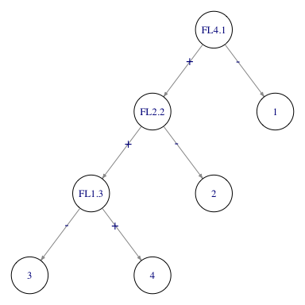

```r
# Plot a graph of the tree (with specific graphical parameters):
plot_graph(Tree, edge.arrow.size = 0.3, Vcex = 0.8, vertex.size = 30)
```

The function `plot_nodes` allows to graphically evaluate the fit of the gaussian family distribution at each node. It can also be used to investigate a particular node:

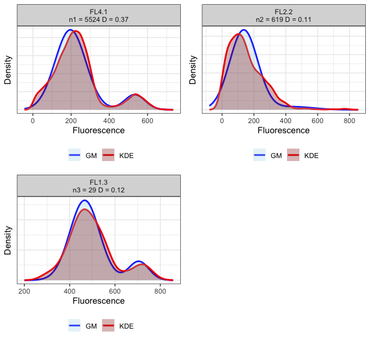

```r
# Plot the distribution fit for each node:
plot_nodes(Tree)
```

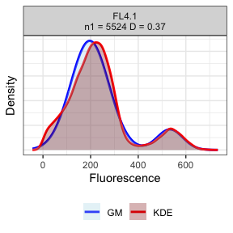

```r
# Plot the distribution fit for a particular node:
plot_nodes(Tree, "FL4.1")
```

### Post-processing annotation of automatically gated subpopulations

The function `Annotation` annotates the subpopulations partitioned by the binary tree:

```r
# Run the annotation algorithm:
Annot <- Annotation(Tree, plot = FALSE)
Annot$combinations
```

```
##   FL1 FL2 FL4 leaves count   prop
## 1   0   1   0      1  4905 0.8879
## 2   0   0   1      2   590 0.1068
## 3   0   1   1      3    25 0.0045
## 4   1   1   1      4     4 0.0007
```

The post-processing annotation can be compared to the incomplete annotation obtained from the tree alone:

```r
# Annotation gotten from the tree:
Tree$annotation
```

```
##   FL1 FL2 FL4 labels count   prop
## 1  NA  NA   0      1  4905 0.8879
## 2  NA   0   1      2   590 0.1068
## 3   0   1   1      3    25 0.0045
## 4   1   1   1      4     4 0.0007
```

This completed annotation eases the search for specific cell types of interest, where `1` represents a positive measurement of a marker, while `0` corresponds to its absence:

```r
# seeked cell type: FL2+FL4+
pheno_ex1 <- RetrievePops(Annot, phenotypes = list(rbind(c("FL2", 1), c("FL4",
    1))))
pheno_ex1$phenotypesinfo
```

```
## [[1]]
## [[1]]$phenotype
## [1] "FL2-1" "FL4-1"
##
## [[1]]$proportion
## [1] 0.0052
##
## [[1]]$Mergedlabels
## [1] 3 4
##
## [[1]]$Newlabel
## [1] 5
```

```r
# One can look for several cell types at once:
phenotypes <- list()
# FL2+FL4-
phenotypes[[1]] <- rbind(c("FL2", 1), c("FL4", 0))
# FL2-FL4+
phenotypes[[2]] <- rbind(c("FL2", 0), c("FL4", 1))
# Retreive corresponding cell populations:
PhenoInfos <- RetrievePops(Annot, phenotypes)
PhenoInfos$phenotypesinfo
```

```
## [[1]]
## [[1]]$phenotype
## [1] "FL2-1" "FL4-0"
##
## [[1]]$proportion
## [1] 0.8879
##
## [[1]]$label
## [1] 1
##
##
## [[2]]
## [[2]]$phenotype
## [1] "FL2-0" "FL4-1"
##
## [[2]]$proportion
## [1] 0.1068
##
## [[2]]$label
## [1] 2
```

### Comparison between manual and automatic gating

Finally, we can compare the automatic gating obtained using `cytometree` to the original manual gating (which had 47 events inconsistently gated across different operators performing the manual gating on those very same data - so those 47 cells were identified as outliers in the reference label and were kept out of the evaluation criteria in the [FlowCAP-I challenge](http://flowcap.flowsite.org/)):

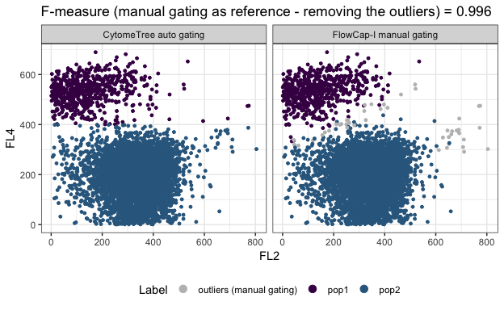

## PBMC sample from the Human Immunology Project

In this example, we will use a dataset from the HIPC ([Human Immunology Project Consortium](https://www.immuneprofiling.org/) program where a PBMC sample from patient 12828 was analyzed by Stanford.

### Automatic gating step

First, we need to load the package `cytometree` and we can have a look at the data:

```r
data(HIPC)
dim(HIPC)
```

```
## [1] 33992     7
```

```r
head(HIPC)
```

```
##           CCR7       CD4   CD45RA      HLADR      CD38      CD8 label
## [1,] 1561.2429 1052.6527 3169.944  889.99200 1326.2701 2733.810     1
## [2,] 1362.2820  978.1219 2826.469 1810.43335 1294.4667 3054.555     1
## [3,] 1321.3787 1180.9497 2780.128  -57.02759  211.0515 2450.657     1
## [4,]  779.8231 1097.8448 3054.914  -67.70583  579.6187 1898.014     1
## [5,]  956.2596  942.8704 2612.188   60.35059 1776.3430 3262.799     1
## [6,] 1100.1621 1080.4724 2560.610  702.39624 1179.5389 2836.238     1
```

We have 6 markers measured `CCR7`, `CD4`, `CD45RA`, `HLADR`, `CD38`, `CD8` as well as the `label` obtained from manual gating, and 33992 cell.

```r
# getting the only the cell events with the 3 markers measured:
cellevents <- HIPC[, c("CCR7", "CD4", "CD45RA", "HLADR", "CD38", "CD8")]
# storing the maanual gating reference from FlowCAP-I:
manual_labels <- HIPC[, "label"]
```

The function `CytomeTree` builds the binary tree according to our algorithm, that gives the automatic gating (given in the resulting `labels` attribute):

```r
# Build the binary tree:
Tree <- CytomeTree(cellevents, minleaf = 1, t = 0.2)
# Retreive the resulting partition (i.e. automatic gating):
Tree_Partition <- Tree$labels
```

One can fiddle with the `t` threshold to change the desired depth of the tree.

The function `plot_graph` plots a graph representing this binary tree, showing which markers were used in which order to splits the events:

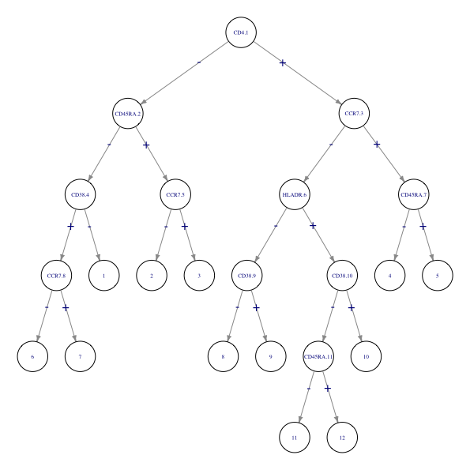

```r
# Plot a graph of the tree (with specific graphical parameters):
plot_graph(Tree, edge.arrow.size = 0.4, Vcex = 0.45)
```

The function `plot_nodes` allows to graphically evaluate the fit of the gaussian family distribution at each node. It can also be used to investigate a particular node:

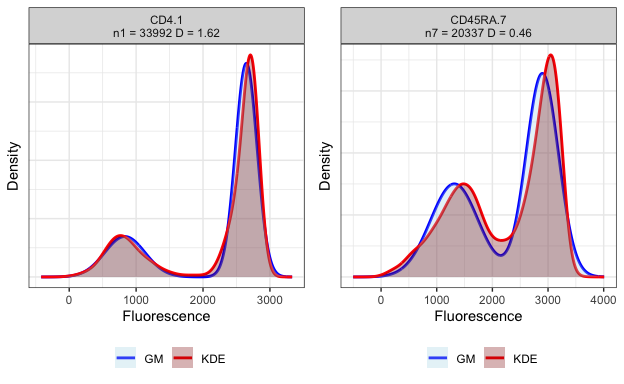

### Post-processing annotation of automatically gated subpopulations

The function `Annotation` annotates the subpopulations partitioned by the binary tree:

```r
# Run the annotation algorithm:
Annot <- Annotation(Tree, plot = FALSE)
Annot$combinations
```

```
##    CCR7 CD4 CD45RA HLADR CD38 CD8 leaves count   prop
## 5     1   1      1     0    1   0      5 12124 0.3567
## 4     1   1      0     0    0   0      4  8213 0.2416
## 3     1   0      1     0    1   1      3  4589 0.1350
## 8     0   1      0     0    0   0      8  4072 0.1198
## 1     0   0      0     0    0   1      1  3136 0.0923
## 2     0   0      1     0    0   1      2   831 0.0244
## 9     0   1      0     0    1   0      9   478 0.0141
## 6     0   0      0     1    1   1      6   193 0.0057
## 10    0   1      0     1    1   0     10   142 0.0042
## 7     1   0      0     1    1   1      7   102 0.0030
## 11    0   1      0     1    0   0     11    84 0.0025
## 12    0   1      1     1    0   0     12    28 0.0008
```

This completed annotation eases the search for specific cell types of interest, where `1` represents a positive measurement of a marker, while `0` corresponds to its absence:

```r
# One can look for several cell types at once:
phenotypes <- list()
# CD8-CD4+CCR7-CD45RA+
CD4effector <- rbind(c("CD8", 0), c("CD4", 1), c("CCR7", 0), c("CD45RA", 1))
phenotypes[[1]] <- CD4effector

# CD8-CD4+CCR7+CD45RA+
CD4naive <- rbind(c("CD8", 0), c("CD4", 1), c("CCR7", 1), c("CD45RA", 1))
phenotypes[[2]] <- CD4naive

# CD8-CD4+CCR7+CD45RA-
CD4CM <- rbind(c("CD8", 0), c("CD4", 1), c("CCR7", 1), c("CD45RA", 0))
phenotypes[[3]] <- CD4CM

# CD8-CD4+CCR7+CD45RA+
CD4effectorM <- rbind(c("CD8", 0), c("CD4", 1), c("CCR7", 0), c("CD45RA", 0))
phenotypes[[4]] <- CD4effectorM

# Retreive corresponding cell populations:
PhenoInfos <- RetrievePops(Annot, phenotypes)
# One can find informations about the seeked phenotypes in
PhenoInfos$phenotypesinfo
```

```
## [[1]]
## [[1]]$phenotype
## [1] "CD8-0"    "CD4-1"    "CCR7-0"   "CD45RA-1"
##
## [[1]]$proportion
## [1] 8e-04
##
## [[1]]$label
## [1] 12
##
##
## [[2]]
## [[2]]$phenotype
## [1] "CD8-0"    "CD4-1"    "CCR7-1"   "CD45RA-1"
##
## [[2]]$proportion
## [1] 0.3567
##
## [[2]]$label
## [1] 5
##
##
## [[3]]
## [[3]]$phenotype
## [1] "CD8-0"    "CD4-1"    "CCR7-1"   "CD45RA-0"
##
## [[3]]$proportion
## [1] 0.2416
##
## [[3]]$label
## [1] 4
##
##
## [[4]]
## [[4]]$phenotype
## [1] "CD8-0"    "CD4-1"    "CCR7-0"   "CD45RA-0"
##
## [[4]]$proportion
## [1] 0.1406
##
## [[4]]$Mergedlabels
## [1]  8  9 10 11
##
## [[4]]$Newlabel
## [1] 13
```

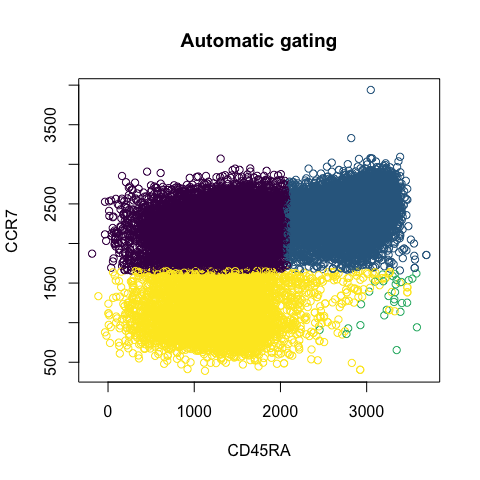

```r
# According to PhenoInfos$phenotypesinfo, CD8-CD4+CCR7-CD45RA+ population is
# labeled 12 According to PhenoInfos$phenotypesinfo, CD8-CD4+CCR7+CD45RA+
# population is labeled 5 According to PhenoInfos$phenotypesinfo,
# CD8-CD4+CCR7+CD45RA- population is labeled 4 According to
# PhenoInfos$phenotypesinfo, CD8-CD4+CCR7+CD45RA+ population is comprised of
# 4 clusters labeled 8,9,10, 11. They were merged into a new cluster labeled
# 13.

# The new partition, with merged clusters is to be found in
# PhenoInfos$Mergedleaves.
auto_labels_merged <- PhenoInfos$Mergedleaves

# Get the indices of the subpopulation comprised of classes labeled 12, 5,
# 4,13.
subpopulation_indices <- auto_labels_merged %in% c(12, 5, 4, 13)

# Scatter plot the data.
CD45RA <- cellevents[subpopulation_indices, "CD45RA"]
CCR7 <- cellevents[subpopulation_indices, "CCR7"]
auto_lab <- factor(auto_labels_merged[subpopulation_indices])
levels(auto_lab) <- viridis::viridis(length(levels(auto_lab)))
auto_lab <- as.character(auto_lab)
plot(CD45RA, CCR7, col = auto_lab, main = "Automatic gating")
```

## Semi-supervised gating

It is possible to force the markers which will be used to gate the data first, using the `force_first_markers` argument of the `CytomeTree()` function. Once those forced markers are used, automatic behavior of the algorithm is resumed for the remaining markers.

```r
# Build the binary tree, forcing the first node to be CD4, and the second
# ones HLADR
Tree <- CytomeTree(cellevents, minleaf = 1, t = 0.2, force_first_markers = c("CD4",
    "HLADR"))
```

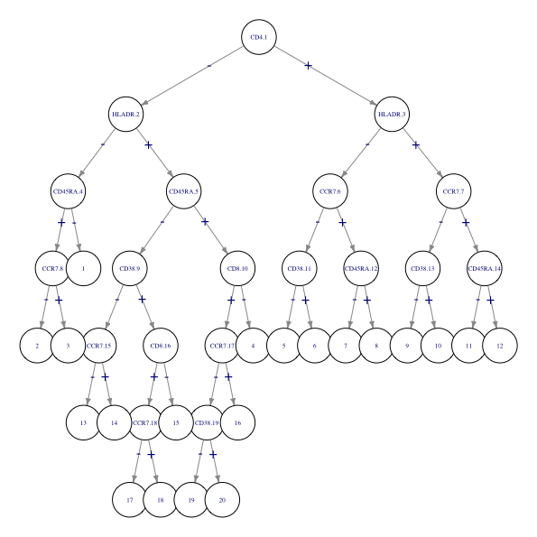

```r
# Plot a graph of the tree (with specific graphical parameters):
plot_graph(Tree, edge.arrow.size = 0.4, Vcex = 0.45)
```